# DFO Reference Points 101

## Exercise 1: Reference points using a Schaefer Surplus Production Model.

A time series of catch (1950-2005) and survey index (1963-1970 and 1975-2005) are provided for a swordfish stock in dataframe **DF**.

The Schaefer model is: *B*<sub>*t*+1</sub> = *B*<sub>*t*</sub> + *rB*<sub>*t*</sub> (1-*B*<sub>*t*</sub>/*K*) - *C*<sub>*t*</sub>

where *B* is biomass, *r* is the intrinsic rate of population growth, *K* is the carrying capacity, *C* is the catch, and *t* is a discrete time period. *B*<sub>MSY</sub> is estimated as *K*/2 and *u*<sub>MSY</sub> is estimated *r*/2.

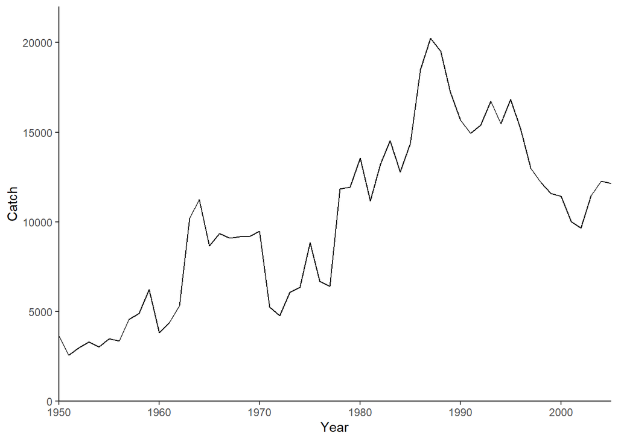

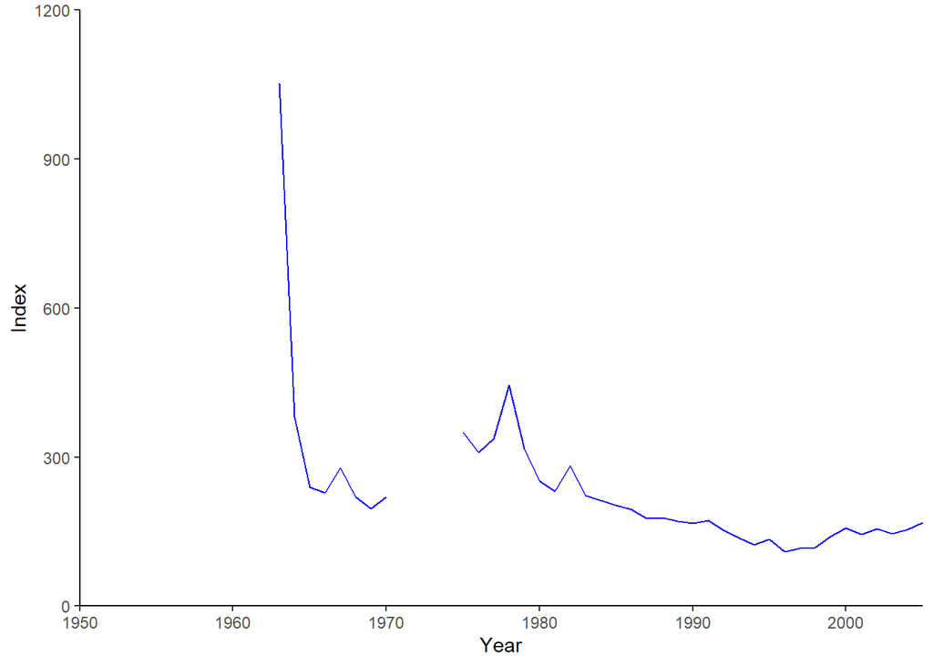

```r
DF <- read.csv("swordfish.csv")
tail(DF)
```

```
##    Year Catch  Index
## 51 2000 11439 156.87
## 52 2001 10011 144.35
## 53 2002  9654 156.10
## 54 2003 11464 146.24
## 55 2004 12265 153.53
## 56 2005 12143 168.26
```

Exercise Questions

1. Estimate *B*<sub>MSY</sub>, MSY, and *u*<sub>MSY</sub> (*u* is used as the harvest rate instead of *F* = instantaneous fishing mortality rate) from the model estimated parameter values (*r* and *K*). Plot the model estimated biomass time series. The Schaefer model can be fit using various software packages. Here we use the SAMtool R package where a data object is created and the Catch, Index, Years, and coefficient of variation for the Index (CV_Ind: needed for model fitting but does not influence model parameter estimates) and used for model fitting.

```r
library(SAMtool)

D <- new('Data')
D@Name <- "swordfish"
D@Cat <- matrix(DF$Catch,nrow=1)
D@Year <- 1950:2005
D@Ind <- matrix(DF$Index,nrow=1)
D@CV_Ind <- matrix(0.3, nrow=1, ncol=length(D@Year))

Model <- SP(Data = D)

K <- Model@TMB_report$K
r <- Model@TMB_report$r

DF$Model_biomass <- Model@B[1:length(D@Year)]
```

2. Project the stock forward 100 years using *u* = 0 and *u*<sub>MSY</sub>. Plot the projected biomass over time and show that the long-term equilibrium biomass values from fishing at *u* = 0 and *u*<sub>MSY</sub> are *K* and *K*/2 = *B*<sub>MSY</sub> estimated from Question 1. The code below will help with the projections (stored in array **P**).

```r
u <- c(0,r/2)
P <- array(NA,dim=c(length(u),100,2),dimnames = list(u,1:100,c("Biomass","Catch")))

terminalB <- DF$Model_biomass[DF$Year==2005]
terminalC <- DF$Catch[DF$Year==2005]

for(i in 1:length(u)){ #loop over u
  for(y in 1:100){     #loop over years
    if(y==1){          #get terminal year (2005) catch and biomass to begin projections for year 1
      lastB <- terminalB
      lastC <- terminalC
    } else {
      lastB <- P[i,(y-1),1]
      lastC <- P[i,(y-1),2]
    }
    P[i,y,1] <- lastB + r*lastB*(1-lastB/K)-lastC # Estimated Biomass from the Schaefer model
    P[i,y,2] <- P[i,y,1]*u[i] # Estimated Catch from the Schaefer model
  }
}
```

3. Project the stock forward 100 years using *u* as a vector from 0 to 1 in steps of 0.001 by modifying the code from Question 2. Plot the long-term equilibrium yield (i.e., Catch) versus *u* and show that the *u* that maximizes yield is the estimate of *u*<sub>MSY</sub> from Question 1.

Solutions:

Question 1

```r
Bmsy <- K/2
Bmsy
```

```
## [1] 51448.72
```

```r
umsy <- r/2
umsy
```

```
## [1] 0.277464
```

```r
MSY <- Bmsy*umsy
MSY
```

```
## [1] 14275.17
```

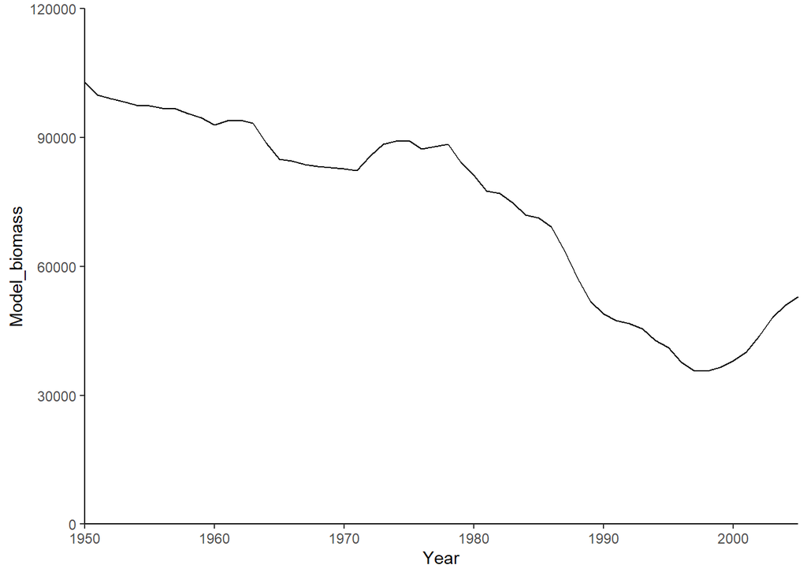

```r
ggplot() + geom_path(data=DF,mapping=aes(y=Model_biomass,x=Year)) + theme_classic()  +
  scale_x_continuous(limits = c(1950,2005), expand = c(0, 0)) +
  scale_y_continuous(limits = c(0,120000), expand = c(0, 0))
```

Question 2

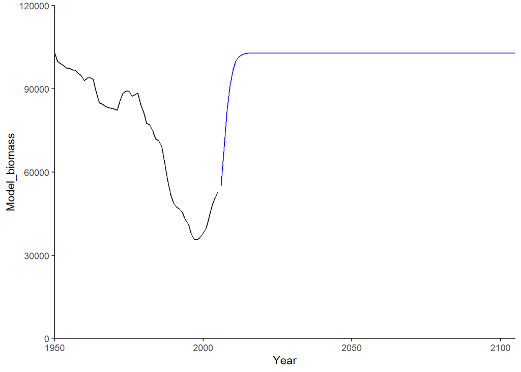

```r
# u = 0
DFu0 <- data.frame(Model_biomass=P[1,,1],Year=2006:(2006+99))
ggplot() + geom_path(data=DF,mapping=aes(y=Model_biomass,x=Year)) + theme_classic()  +
  scale_x_continuous(limits = c(1950,(2005+100)), expand = c(0, 0)) +
  scale_y_continuous(limits = c(0,120000), expand = c(0, 0)) +
  geom_path(data=DFu0,mapping=aes(y=Model_biomass,x=Year),colour="blue")
```

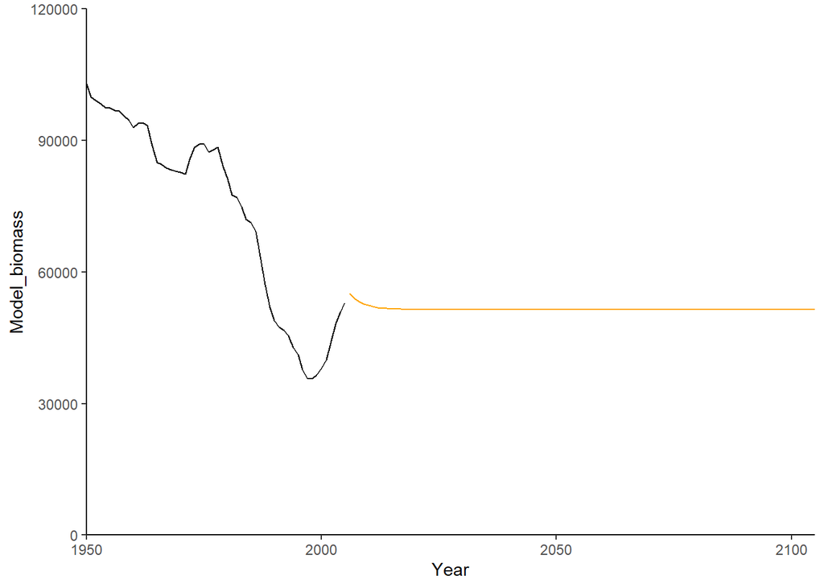

```r
# u = umsy
DFumsy <- data.frame(Model_biomass=P[2,,1],Year=2006:(2006+99))
ggplot() + geom_path(data=DF,mapping=aes(y=Model_biomass,x=Year)) + theme_classic()  +
  scale_x_continuous(limits = c(1950,(2005+100)), expand = c(0, 0)) +
  scale_y_continuous(limits = c(0,120000), expand = c(0, 0)) +
  geom_path(data=DFumsy,mapping=aes(y=Model_biomass,x=Year),colour="orange")
```

```r
# used last 50 years for equilibrium
# u = 0 and u = msy
projected_equilbrium_B <- apply(P[,51:100,1],1,mean)
projected_equilbrium_B
```

```
##                 0 0.277463962406989
##         102897.44          51448.72
```

Question 3

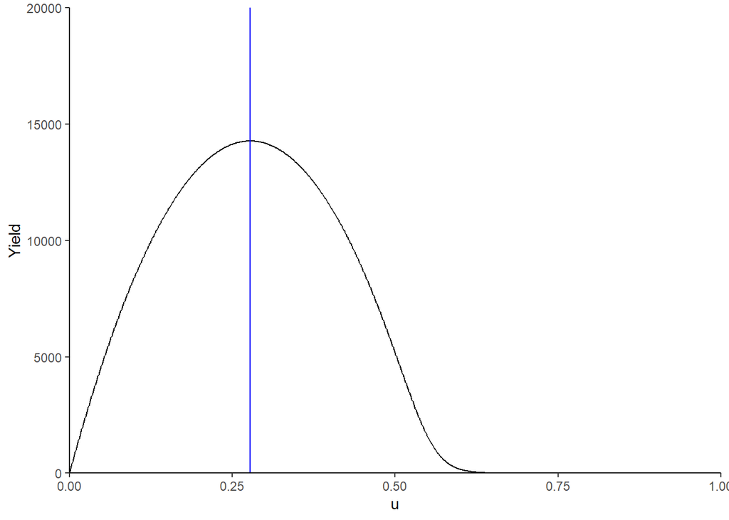

```r
u <- seq(0,1,0.001)
P <- array(NA,dim=c(length(u),100,2),dimnames = list(u,1:100,c("Biomass","Catch")))

terminalB <- DF$Model_biomass[DF$Year==2005]
terminalC <- DF$Catch[DF$Year==2005]

for(i in 1:length(u)){
  for(y in 1:100){
    if(y==1){
      lastB <- terminalB
      lastC <- terminalC
    } else {
      lastB <- P[i,(y-1),1]
      lastC <- P[i,(y-1),2]
    }
    P[i,y,1] <- lastB + r*lastB*(1-lastB/K)-lastC
    P[i,y,2] <- P[i,y,1]*u[i]
  }
}

# used last 50 years for equilibrium
EX3 <- data.frame(u=u,Yield = apply(P[,51:100,2],1,mean),equil_B = apply(P[,51:100,1],1,mean))
ggplot(EX3)+geom_path(mapping=aes(y=Yield ,x=u)) + theme_classic() +
  scale_x_continuous(limits = c(0,1), expand = c(0,0)) +
  scale_y_continuous(limits = c(0,20000), expand = c(0,0)) +
  # add vertical line at umsy estimated from model parameter r
  geom_vline(xintercept = r/2, linetype = 1, colour = "blue")
```